# Homework 9

Carmen Canedo

28 November 2020

# Exercise 1

## Question 1: Explore the distribution of `rincome` (reported income). What makes the default bar chart hard to understand? How could you improve the plot?

This is hard to understand because:

1. The labels on the x-axis are illegible because they are overlapping.
2. Includes “No answer” values

To improve it, I would use `coord_flip()` so that the labels are legible, remove non-response values, and sort count in ascending order.

## Question 2: What is the most common religion? Most common `partyid`?

The most common religion is Protestantism.

The most common political party is Independent. However, the levels for each party are split, so I wonder if they are combined if it would change which is the most common political party.

## Question 3: Which `relig` does `denom` apply to? How can you find out with a table? How can you find out with a vizualization?

To find out what `relig` `denom` belongs to, we can check the levels to see if they give us any further details.

The levels are all Protestant denominations, so we can assume that `denom` belongs to `Protestant`.

## Question 4: How have the proportions of people identifying as Democrat, Republican, and Independent changed over time?

The levels for the parties are split, so if we are going to look at their overall change, we need to combine them using `fct_collapse()`, and then we need to calculate the proportion of them by year.

## Question 5: How could you collapse `rincome` into a small set of categories?

The levels for `rincome` are not broken down into even groups, so to decrease the number of categories, I am going to try to aim for each category to increase by about $5000.

The first thing to do would be to collapse the non-responses into a group called `Other`. Then we will need to use `str_c()` from the `stringr` package to dilineate the new levels.

I will be using the following levels:

# Exercise 2

## Question 1: Parse the following date-times

“05/26/2004 UTC 11:11:11.444”  
“26 2004 05 UTC 11/11/11.444”

```
[1] "2004-05-26 11:11:11 UTC"
```

## Question 3: For each month in `wmata_ridership`, calculate the proportion of rides made on a given day of the month. Then make box plots of the proportions of ridership vs. day of the week, *excluding any days from 2004*.

[output not shown]

[output not shown]

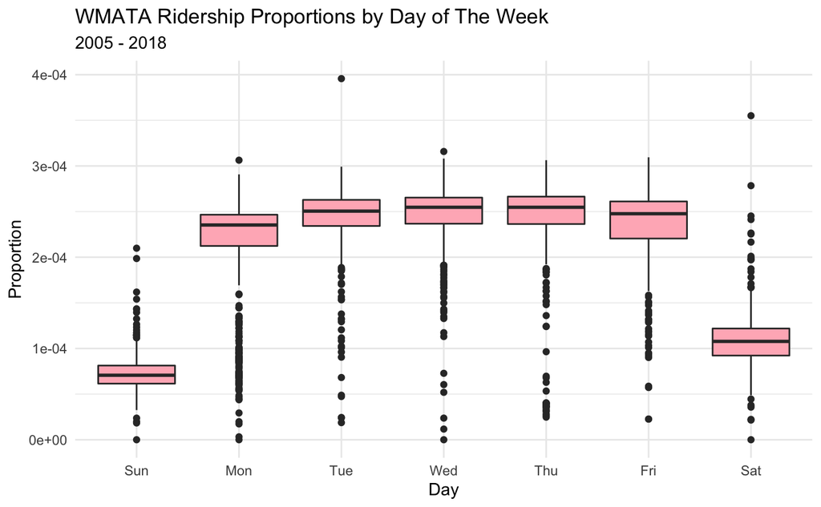

## Question 4: How long of a time-span is covered in the WMATA ridership dataset?

```
[1] "472435200s (~14.97 years)"
```